# R 성능개선

#### 2.머신러닝에서 앙상블이란?

> 약한 학습자 여러개를 결합해서 보다 더 나은 강한 학습자를 만드는 기법

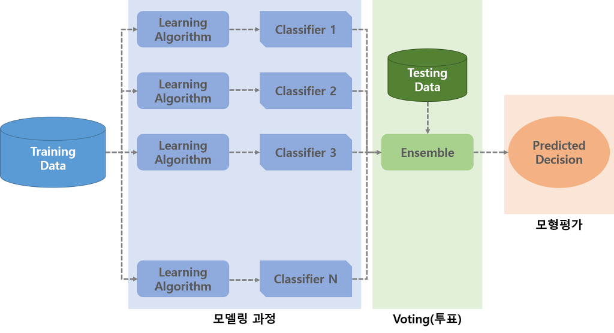

#### 예제: 정확도가 60% 밖에 되지 않는 분류기 모형들이 즐비한데 이모형들을 여러개 모아서 한꺼번에 평가하는 모형을 만드는데 60%밖에 되지 않는 분류기들을 90% 이상을 능가하게 만들려면 이 모형을 최소 몇개를 사용해야 90%이상 나올 수 있는가?

```r
ret_err <- function(n,err) {

  sum <- 0
  for(i in floor(n/2):n) {
    sum <- sum + choose(n,i) * err^i * (1-err)^(n-i)
  }
  sum
}

for(j in 1:60) {
  err <- ret_err(j , 0.4)
  cat(j,'--->',1-err,'\n')
  if(1-err >= 0.9) break
}
```

```
## 1 ---> 0
## 2 ---> 0.36
## 3 ---> 0.216
## 4 ---> 0.4752
## 5 ---> 0.33696
## 6 ---> 0.54432
## 7 ---> 0.419904
## 8 ---> 0.5940864
## 9 ---> 0.4826097
## 10 ---> 0.6331033
## 11 ---> 0.5327742
## 12 ---> 0.6652086
## 13 ---> 0.5743964
## 14 ---> 0.6924522
## 15 ---> 0.6098132
```

[output cut: 35 more lines]

#### Bagging

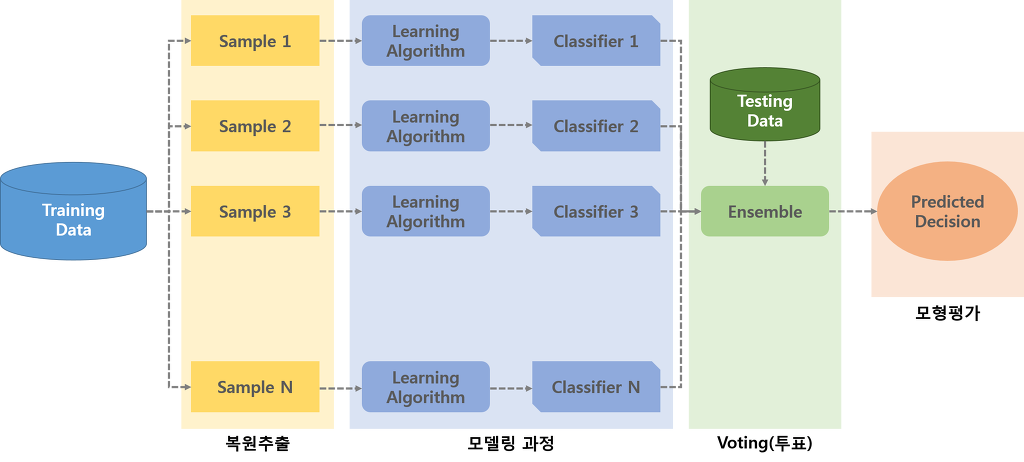

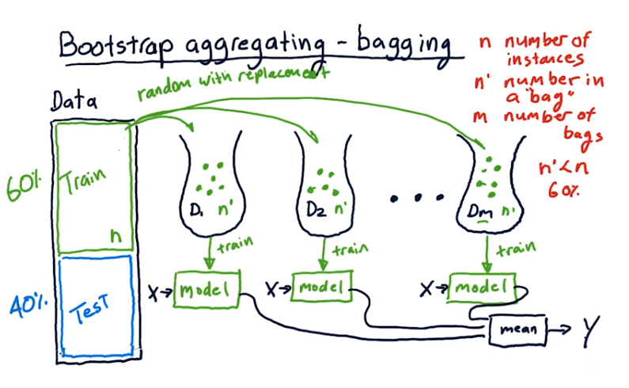